# Exploratory analysis redux

## Punchlines:

- Read your words out loud to check that they make sense and use the spell check.
- Questions should be about one or more variables in the data.
- Be *specific* and *precise* about what are you asking about.
- Questions should not be very creative. Don’t overthink - keep it simple!
  - “Reverse engineering” questions from creative plots can lead to questions that don’t make sense.
- Limit questions to the scope of the data. Being too fancy = being wrong.
- *Do not even think about cause and effect unless the data was an experiment evaluating cause and effect.*

## Good (non-creative!) places to explore

- Distributions of a numeric variable
  - Shape and skew, mean/median, range, spread
- Counts of a categorical variable
- Relationships between variables. *Seriously, never cause/effect.*
  - Relationship between two numeric variables - positive? negative? strong? weak?
  - Relationship between two categorical variables - joint counts!
  - Relationship between numeric and categorical - “how do means compare?” etc.

## Peer review of student exploratory analyses

#### How many bins are in the histogram?

There are 14 bins in the histogram.

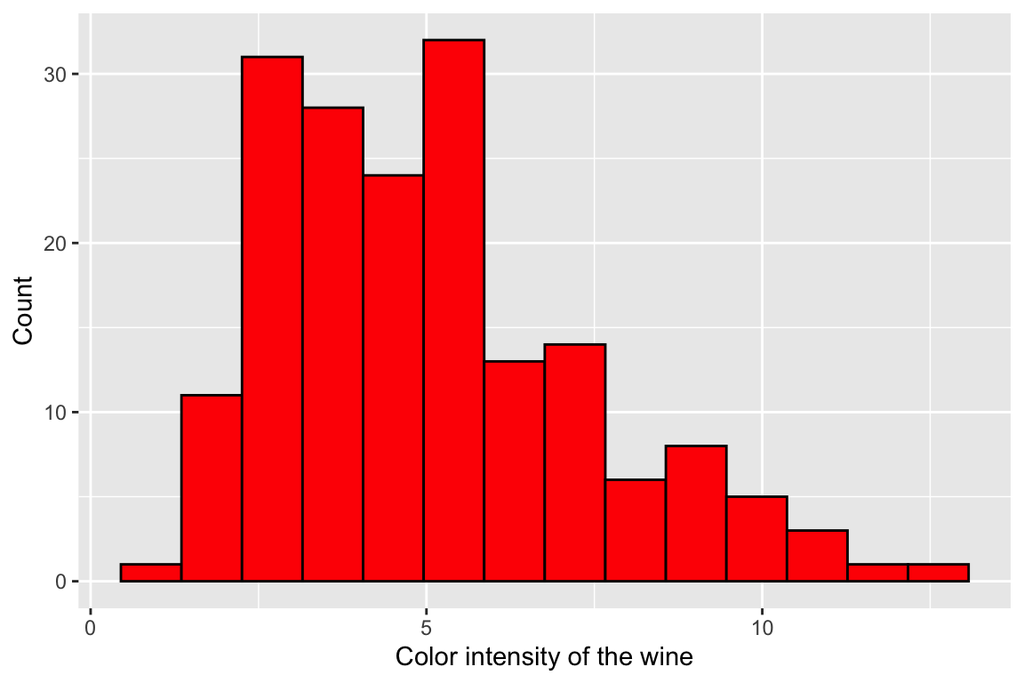

```r
ggplot(wine) +
  aes(x = color) +
  geom_histogram(color = "black",
                 fill = "red",
                 bins = 14) +
  labs(x = "Color intensity of the wine",
       y = "Count")
```

#### What is the difference between the disbutions?

Females wing size tends to be larger than males.

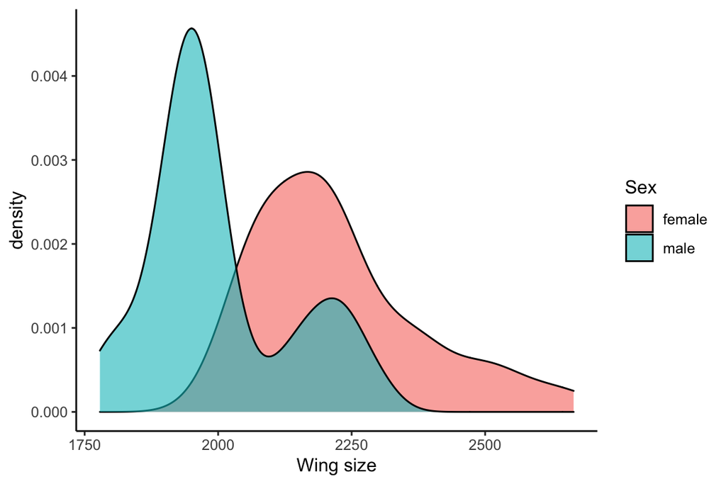

```r
ggplot(damselfly) +
  aes(x = Wing.size, fill = Sex) +
  geom_density(alpha = 0.6) +
  labs(x = " Wing size ") +
  theme_classic()
```

#### Is the distribution of urea unimodal, bimodal, or multimodal in this histogram?

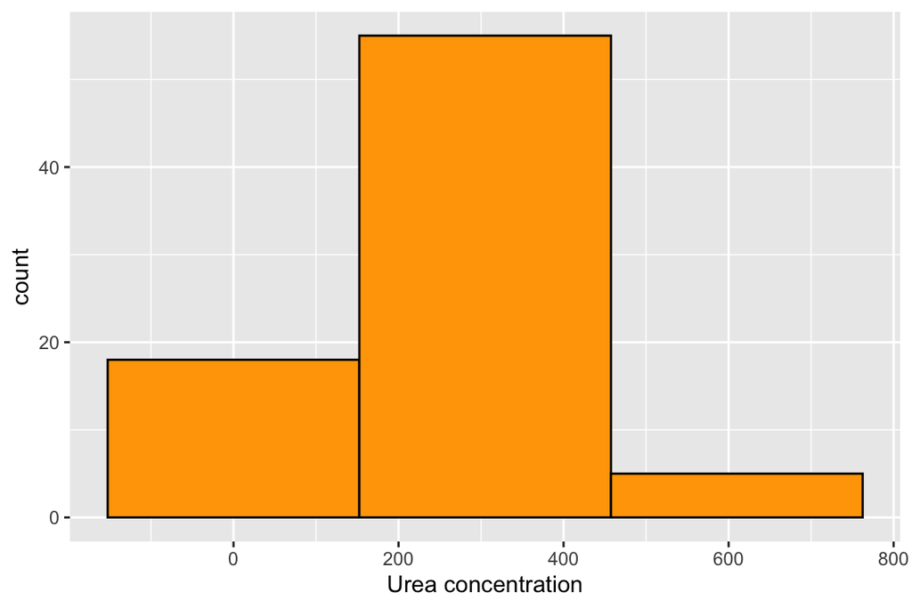

```r
ggplot(urine) +
  aes(x = urea) +
  geom_histogram(fill = "orange1",
                 color = "black",
                 size = 0.5,
                 bins = 3) +
  labs(x = "Urea concentration",
       y = "count")
```

#### Is there a relationship between osmolarity of urine and specific gravity of urine?

Yes there exists a positive relationship between the two. As osmolarity increases, specific gravity increases as well.

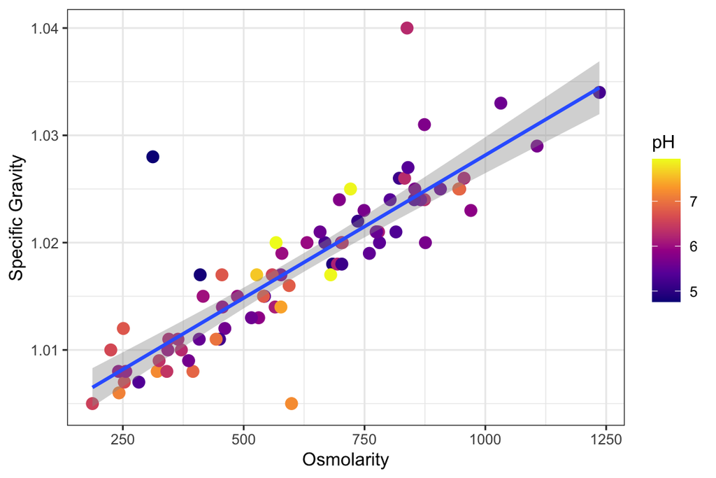

```r
ggplot(urine) +
  aes(x = osmo,
      color = pH,
      y = gravity) +
  geom_point(size = 3) +
  geom_smooth(method = "lm") +
  scale_color_viridis_c(option = "plasma") +
  labs(x = "Osmolarity",
       y = "Specific Gravity") +
  theme_bw()
```

#### What is the relationship between the body mass and age of women, for whether or not they have diabetes?

There is no relationship overall because the trend line is flat.

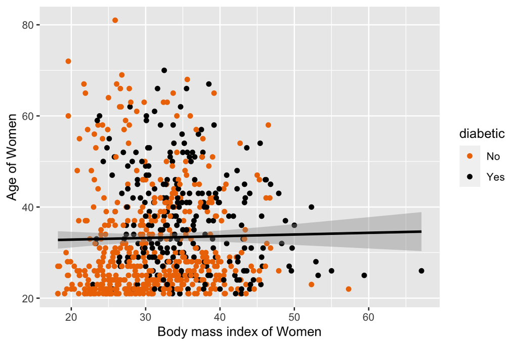

```r
ggplot(pima) +
  aes(x = bmi,
      y = age,
      color = diabetic) + # added color to aes to map color to diabetic
  geom_point() +
  scale_color_manual(values = c("darkorange2",
                               "black")) +
    geom_smooth(method = "lm", color = "black") + # added color to trendline and used function "lm" for trendline
  labs(x = "Body mass index of Women",
       y = "Age of Women")
```

#### Is a person with a higher urea concentration more likely to have kidney stones?

As urea concentration increase the likelihood of crystal formation of kidney stones is more likely to occur as seen as a higher density of those with crystals have a high concentration of urea.

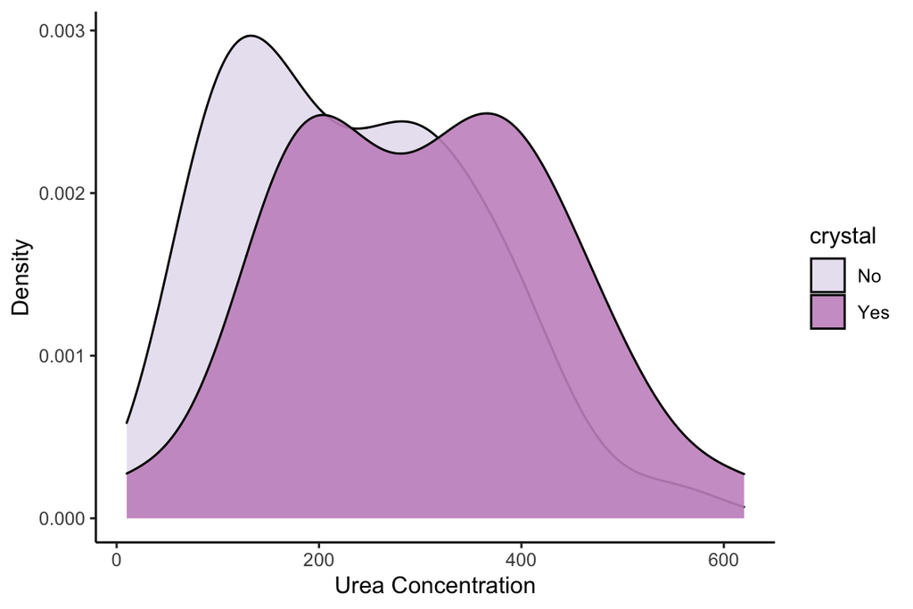

```r
ggplot(urine) +
  aes(x = urea,
      fill = crystal) +
  geom_density(color = "black",
               alpha = 0.90) +
  scale_fill_brewer(palette = "PuRd") +
  theme_classic() +
  labs(x = "Urea Concentration", y = "Density")
```

#### Is there a BMI that women did not have have any pregnancies?

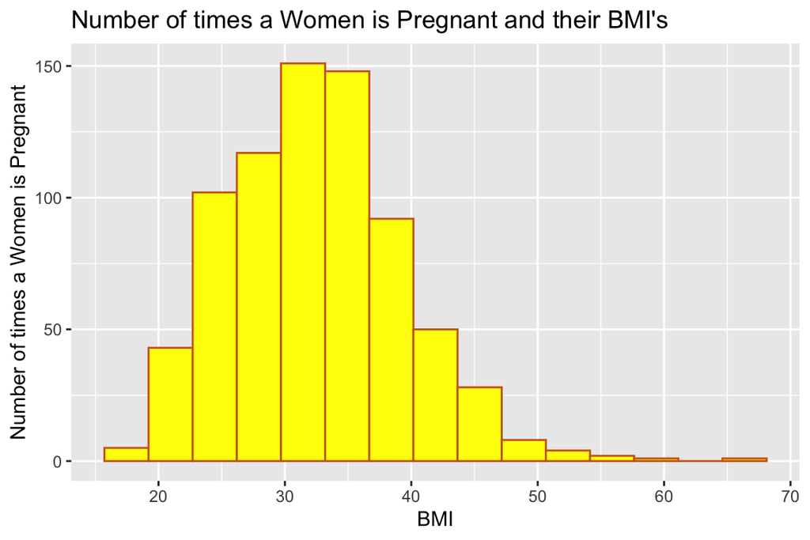

```r
ggplot(pima) +
  aes(x = bmi) +
  geom_histogram(fill = "yellow",
                 color = "chocolate3", bins = 15) +
  labs(x = "BMI", #labels
       y = "Number of times a Women is Pregnant",
       title = "Number of times a Women is Pregnant and their BMI's")
```

#### What is the higest insulin vaule in people without diabetes ?

The highest insulin value for people with out diabetes is around 750.

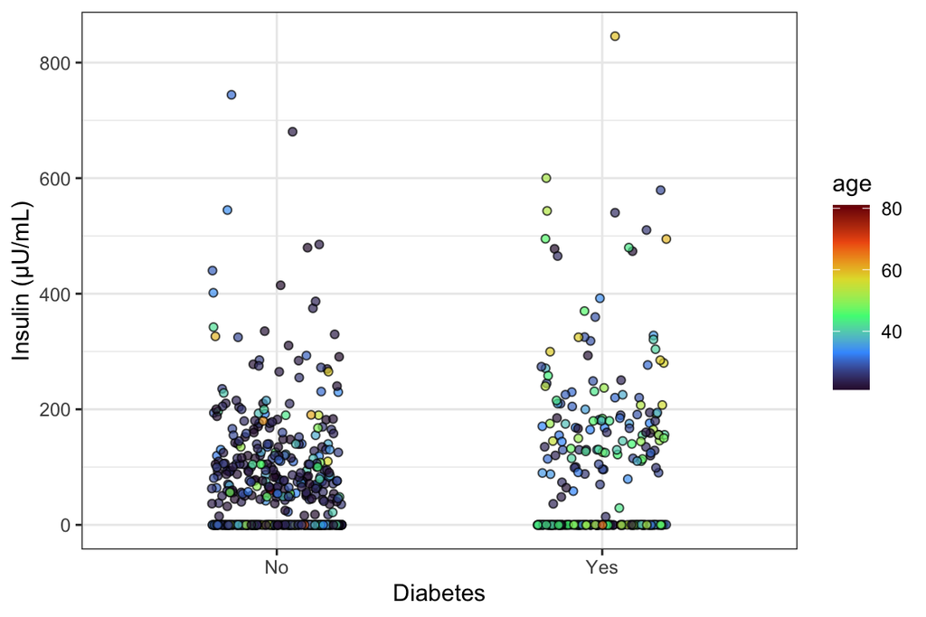

```r
ggplot(pima)+
  aes(x=diabetic,
      y=insulin,
      fill=age)+
  geom_jitter(shape=21,
             alpha=0.7,
             width=0.2)+
  scale_fill_viridis_c(option="turbo")+
  theme_bw()+
  labs(x="Diabetes",
       y="Insulin (μU/mL)")
```

#### Is there sexual selection for wing size?

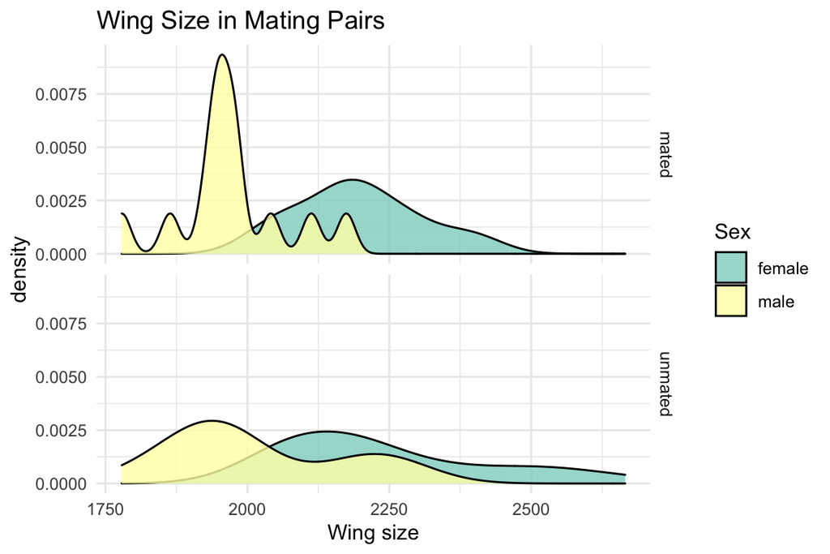

```r
ggplot(damselfly) +
  aes(x = Wing.size, fill = Sex) +
   scale_fill_brewer(palette = "Set3") +
  geom_density(alpha = 0.8) +
  facet_grid(vars(Mating.status)) +
  theme_minimal() +
  labs(x = "Wing size",
       title = "Wing Size in Mating Pairs")
```

#### Does abdomen length play a role in damsel fly sexual selection?

Abdomen length seems to play a role in damsel fly sexual selection, as those with smaller abdomens seem to be more likely to be mated. This was not what I actually expected.

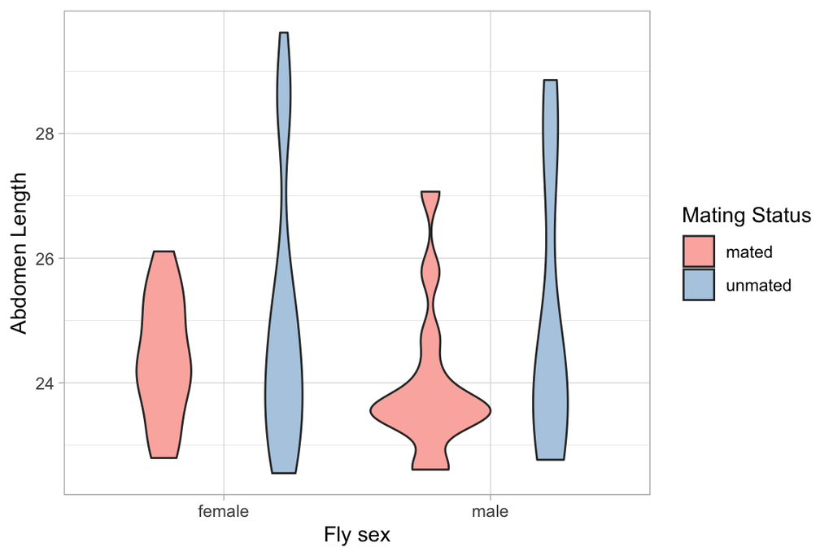

```r
ggplot(damselfly)+
  aes(fill=Mating.status, y=Abdomen.length, x=Sex)+
  geom_violin()+
  labs(x="Fly sex",
       y="Abdomen Length",
       fill="Mating Status")+
  scale_fill_brewer(palette="Pastel1")+
  theme_light()
```